# Logistic Regression Projects - **Gianna Rosero**

In this project, I explored binary outcomes using logistic regression to understand how predictor variables affect the probability of success or failure. I analyzed two real-world datasets:

1. **Management Consultants:**

   Investigated whether a consultant’s years of experience predicts task success. Using `ggplot2`, I visualized experience distributions and then modeled success probability using logistic regression. I interpreted the model’s coefficients, calculated odds ratios, and visualized predicted probabilities using the `marginaleffects` package.
2. **Daphnid Toxicity Study:**

   Analyzed how exposure dose and time affect the probability of daphnid immobility in a controlled experiment. Since each row represented grouped outcomes (e.g., number immobile out of 20), I used a binomial logistic model with grouped data. I interpreted model output and visualized the predicted probability of immobility by dose and time, highlighting the toxic effects over time and increasing dosage.

## **Packages**

```r
library(tidyverse)
library(marginaleffects)
```

## **Management consultants**

```r
my_url <- "http://ritsokiguess.site/datafiles/ex_13-25.csv"
consultant <- read_csv(my_url)
consultant
```

| completion | experience |
| --- | --- |
| Failure | 4 |
| Failure | 5 |
| Failure | 6 |
| Failure | 9 |
| Failure | 10 |
| Failure | 11 |
| Failure | 11 |
| Failure | 13 |
| Failure | 15 |
| Failure | 18 |

[output cut: 18 more lines]

2. Make a suitable graph of the data, interpret the graph, and explain briefly why the graph does not tell you what you really want to know (or does tell you, if you think it does).

1 categorical and 1 quantitative thus we use a boxplot.

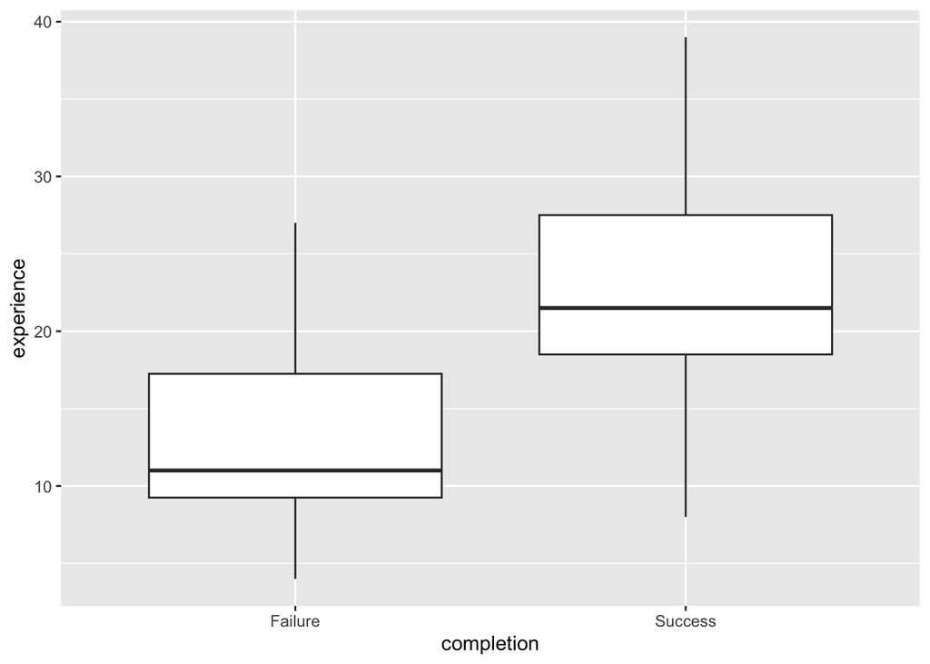

```r
ggplot(consultant, aes(x = completion, y = experience)) + geom_boxplot()
```

The boxplot shows the distribution of experience for consultants based on task completion status (Success or Failure). Consultants who succeeded generally have higher experience, as indicated by a higher median and interquartile range, while those who failed tend to have lower experience. However, the boxplot does not quantify the probability of success or account for variability, making it insufficient to fully understand the relationship. A logistic regression model is needed to analyze the effect of experience on the likelihood of success more precisely.

3. Fit a suitable logistic regression, and display the results. (Hint: what is your response variable? Are its values what they need to be?)

The response variable is competition. The values need to be in factor format with two levels.

```r
#make response into a factor
consultant.1 <- consultant %>%
  mutate(completion = factor(completion, levels = c("Failure", "Success")))
```

```r
completion.1 <- glm(completion ~ experience, family = "binomial", data = consultant.1)
summary(completion.1)
```

```
Call:
glm(formula = completion ~ experience, family = "binomial", data = consultant.1)

Coefficients:
            Estimate Std. Error z value Pr(>|z|)
(Intercept) -3.02597    1.25190  -2.417   0.0156 *
experience   0.17303    0.06773   2.555   0.0106 *
---
Signif. codes:  0 '***' 0.001 '**' 0.01 '*' 0.05 '.' 0.1 ' ' 1

(Dispersion parameter for binomial family taken to be 1)

    Null deviance: 38.816  on 27  degrees of freedom
Residual deviance: 28.950  on 26  degrees of freedom
AIC: 32.95

Number of Fisher Scoring iterations: 4
```

4. How does your output tell you that more experience goes with a *greater* probability of success at the task? There are *two* things to say, neither of which have anything (here) to do with statistical significance.

The coefficient for `experience` is 0.17303, as shown in the summary output. A positive coefficient means that as `experience` increases, the log-odds of success also increase. Specifically, for every additional unit of experience, the log-odds of success increase by 0.17303.

```r
exp(0.17303)
```

```
[1] 1.188902
```

When the coefficient for `experience` is exponentiated, the odds ratio is approximately 1.189. This means that for every additional unit of experience, the odds of success increase by about 18.9%.

5. Using a suitable package, make a plot of success probability as it depends on experience, including a (95%) confidence interval for success probability for each amount of experience. How does your plot suggest that there is a *significant* relationship between experience and success at the task?

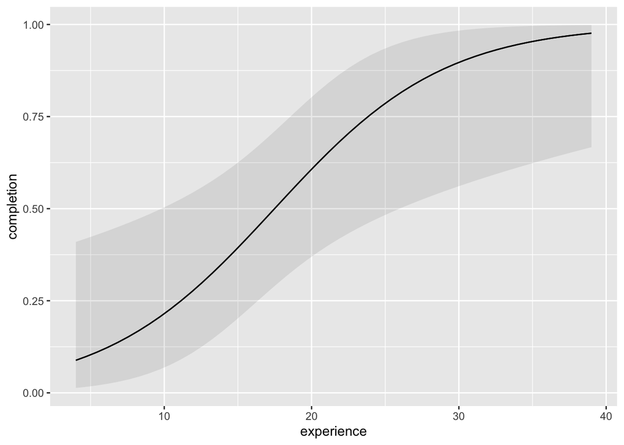

```r
plot_predictions(model = completion.1,condition = "experience")
```

## **Daphnids**

```r
my_url <- "http://ritsokiguess.site/datafiles/drc_daphnids.csv"
daphnids <- read_csv(my_url)
```

```r
daphnids
```

| dose | no | total | time |
| --- | --- | --- | --- |
| 105.00 | 0 | 20 | 24h |
| 400.07 | 1 | 20 | 24h |
| 600.10 | 3 | 20 | 24h |
| 1199.20 | 3 | 20 | 24h |
| 1999.33 | 5 | 20 | 24h |
| 3198.52 | 6 | 20 | 24h |
| 5596.91 | 7 | 20 | 24h |
| 9595.57 | 17 | 20 | 24h |
| 105.00 | 0 | 20 | 48h |
| 400.07 | 0 | 20 | 48h |

[output cut: 6 more lines]

7. Does each row of your dataframe contain one observation, or more than one? Explain briefly.

Each row of the dataframe contains more than one observation because the `no` column represents the number of immobile daphnids out of the 20 exposed in each combination of `dose` and `time`. This means that each row summarizes the outcomes for a group of 20 daphnids rather than a single daphnid.

8. Fit a model predicting the probability that a daphnid is *immobile* given its dose and time. Display the results.

```r
#add column for # of moblie daphnids
daphnids <- daphnids %>% mutate(mobile = 20 - no)
```

```r
daphnids.1 <- glm(cbind(no, mobile) ~ dose + time, family = "binomial", data = daphnids)
summary(daphnids.1)
```

```
Call:
glm(formula = cbind(no, mobile) ~ dose + time, family = "binomial",
    data = daphnids)

Coefficients:
              Estimate Std. Error z value Pr(>|z|)
(Intercept) -2.987e+00  3.418e-01  -8.739  < 2e-16 ***
dose         5.650e-04  6.864e-05   8.231  < 2e-16 ***
time48h      1.625e+00  3.273e-01   4.966 6.85e-07 ***
---
Signif. codes:  0 '***' 0.001 '**' 0.01 '*' 0.05 '.' 0.1 ' ' 1

(Dispersion parameter for binomial family taken to be 1)

    Null deviance: 181.017  on 15  degrees of freedom
Residual deviance:  37.521  on 13  degrees of freedom
AIC: 79.597

Number of Fisher Scoring iterations: 5
```

9. From your output in question 8, interpret the number in the `time` row and the `Estimate` column, as far as you are able.

Since the estimate is positive (1.625e+00), increasing the exposure time from 24 hours to 48 hours increases the likelihood of a daphnid becoming immobile. We can only calculate the odds ratio.:

```r
exp(1.625)
```

```
[1] 5.078419
```

This means that the odds of a daphnid being immobile at 48 hours are approximately 5.08 times higher than at 24 hours, when the dose is held constant.

10. Plot the predicted probabilities that a daphnid is immobile against dose and time, with confidence intervals for each probability.

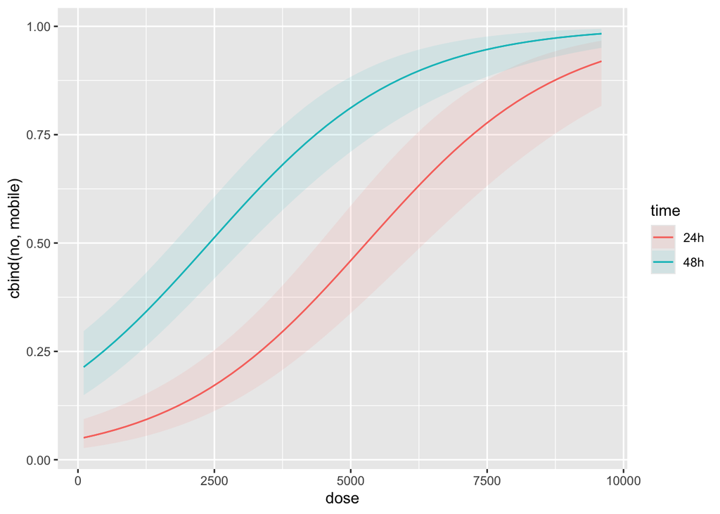

```r
plot_predictions(daphnids.1, condition = c("dose", "time"))
```

11. What does your plot from question 10 tell you about the relationship between the probability of a daphnid being immobile as it depends on `dose` and `time`?

The plot shows that the probability of a daphnid being immobile increases with higher doses of the toxic substance, represented by red (24-hour exposure) and blue (48-hour exposure). The 48-hour group consistently exhibits a higher probability of immobility than the 24-hour group, indicating that longer exposure rasies the toxin’s effect. The shaded regions around each curve show narrow confidence intervals, which shows the reliability of the model’s predictions. Overall, both dose and time strongly influence immobility, with dose being the primary driver.